*Máster Universitario en Inteligencia Artificial*

# Análisis de reducción de dimensionalidad: PCA y t-SNE

## Objetivo General

En este trabajo, se busca que pongas en práctica la aplicación de algoritmos de reducción de dimensionalidad. El objetivo es aplicar técnicas para reducir la dimensionalidad a 2D, graficar los resultados y seleccionar la mejor técnica para los datos. Además, deberás detallar los pasos a seguir para la reducción de dimensionalidad y analizar los resultados obtenidos.

### Objetivos específicos

- Entender los métodos de t-SNE y PCA.
- Realizar la reducción de dimensionalidad utilizando t-SNE y PCA.
- Comparar los resultados obtenidos con ambos métodos.
- Aplicar LDA para reducir el dataset a una bolsa de palabras por cada etiqueta.

### Tareas a Realizar:

Debes realizar esta actividad en el Notebook adjunto. A medida que avances, completa el código solicitado y responde a las preguntas que se plantean. Las tareas a realizar son:

- Reducción de Dimensionalidad con t-SNE y PCA:
- Completa el código proporcionado en el notebook.
- Responde a las preguntas finales sobre los resultados obtenidos.

#### Punto adicional: Aplicación de LDA:

Utiliza la técnica de LDA para generar una bolsa de palabras para cada una de las etiquetas.

### Coloca en este espacio el nombre del estudiante

```python
# Sergio Gómez Martín (53775841R)
```

### Dataset

#### Dataset

El dataset original proporcionado en el proyecto transversal ha sido adaptado para la realización de esta actividad. Esa adaptación ha incluido:

- Eliminación de nulos y duplicados
- Eliminación de URLs, emojis y menciones a los periódicos
- Eliminación de filas vacías
- Limpieza y homogeneización de datos.
- Convertir la totalidad del texto a minúscula
- Eliminar signos de puntuación
- Eliminar números
- Eliminar espacios en blanco adicionales
- Eliminar palabras con longitud menor a 2 caracteres
- Eliminar stopwords
- Tokenización
- Lematización

Proceso de extracción de características

- Conteo de palabras positivas (A)
- Conteo de palabras negativas (B)
- Conteo del número de bigrams más comunes (C)
- Conteo del número de menciones a otros usuarios (D)
- Categoría del sentimiento según librería ‘pysentimiento’ en español (E)
- Estandarización de las características (A_t,..E_t)
- Combinación de características f1*fi (iA..iE) (Valor1,..Valor10).

### Lectura de datos

```python
import pandas as pd
import numpy as np
import matplotlib.pyplot as plt

# Leer el archivo CSV
file_path = 'out.csv'
data = pd.read_csv(file_path)

# Obtener el número de filas y columnas
num_filas, num_columnas = data.shape

# Mostrar el número de filas y columnas
print(f"El dataset tiene {num_filas} filas y {num_columnas} columnas.")
```

```
El dataset tiene 10000 filas y 22 columnas.
```

```python
data.head()
```

|  | A | B | C | D | E | comentario | label | A_t | B_t | C_t | ... | Valor_1 | Valor_2 | Valor_3 | Valor_4 | Valor_5 | Valor_6 | Valor_7 | Valor_8 | Valor_9 | Valor_10 |
| --- | --- | --- | --- | --- | --- | --- | --- | --- | --- | --- | --- | --- | --- | --- | --- | --- | --- | --- | --- | --- | --- |
| 0 | 2 | 64 | 30 | 0 | 2 | pandemia,originado,covid,cierto,incidencia,aba... | 0.0 | 1.851102 | 2.759647 | 7.145831 | ... | 5.108388 | 13.227660 | -0.771127 | 0.815665 | 19.719970 | -1.149606 | 1.216004 | -2.976790 | 3.148722 | -0.183560 |
| 1 | 4 | 70 | 21 | 0 | 0 | ser,mes,larga,espera,llegar,momento,siempre,pr... | 0.0 | 3.990202 | 3.054765 | 4.877255 | ... | 12.189130 | 19.461233 | -1.662227 | -2.119191 | 14.898871 | -1.272546 | -1.622382 | -2.031754 | -2.590305 | 0.221244 |
| 2 | 4 | 88 | 50 | 0 | 0 | cartagena,san,sebastiar,fuengirola,irun,orense... | 0.0 | 3.990202 | 3.940120 | 12.187108 | ... | 15.721875 | 48.629021 | -1.662227 | -2.119191 | 48.018675 | -1.641365 | -2.092593 | -5.076872 | -6.472559 | 0.221244 |
| 3 | 3 | 38 | 21 | 0 | 0 | pleno,dia,verano,calor,plan,mas,apetecibl,disf... | 0.0 | 2.920652 | 1.480801 | 4.877255 | ... | 4.324903 | 14.244765 | -1.216677 | -1.551155 | 7.222244 | -0.616868 | -0.786452 | -2.031754 | -2.590305 | 0.221244 |
| 4 | 0 | 59 | 17 | 0 | 0 | pasado,junio,celebro,dia,luchar,frente,leishma... | 0.0 | -0.287998 | 2.513715 | 3.869000 | ... | -0.723945 | -1.114264 | 0.119973 | 0.152955 | 9.725563 | -1.047156 | -1.335031 | -1.611737 | -2.054821 | 0.221244 |

5 rows × 22 columns

```python
##Cuántas categorías hay en la columna label
# Contar el número de categorías únicas en la columna 'label'

num_categorias = data['label'].nunique()
print(f"Numero de categorias en label: {num_categorias}")

categorias = data['label'].unique()
print(f"Categorías: {categorias}")
```

```
Numero de categorias en label: 2
Categorías: [0. 1.]
```

Con el código anterior se obtienen tanto el número de categorías como las propias categorías. Se observa que hay dos categorías, que son 0 y 1. Si se tiene en cuenta que este dataset pertenece al proyecto transversal, este era un corpus que contenía mensajes publicados en redes sociales. El objetivo era predecir si cada mensaje pertenecía a la categoría 'Odio' o 'No Odio'. De esta manera, generar un clasificador de mensajes de odio. Interpretando las label, 0 correspondería a 'No Odio' y 1, a 'Odio'.

```python
# Obtener estadísticas descriptivas de las variables numéricas
estadisticas = data.describe()
print(estadisticas)

# Obtener la frecuencia de las categorías en la columna 'label'
frecuencia = data['label'].value_counts()
print(frecuencia)

porcentaje = data['label'].value_counts(normalize=True) * 100
print("\nPorcentaje de cada categoría:")
print(porcentaje)

# Mostrar las estadísticas y la frecuencia de las categorías
```

```
                  A             B             C             D             E  \
count  10000.000000  10000.000000  10000.000000  10000.000000  10000.000000
mean       0.957400     26.098100      5.674600      0.091300      2.200600
std        1.741864     34.012341      7.317149      0.352671      2.729488
min        0.000000      0.000000      0.000000      0.000000      0.000000
25%        0.000000      1.000000      1.000000      0.000000      0.000000
50%        0.000000      5.000000      3.000000      0.000000      0.000000
75%        1.000000     46.000000      7.000000      0.000000      6.000000
max       24.000000    328.000000     88.000000      6.000000      6.000000

              label           A_t           B_t           C_t           D_t  \
count  10000.000000  10000.000000  10000.000000  10000.000000  10000.000000
mean       0.500000      0.735989      0.895389      1.014276     -0.241571
std        0.500025      1.863010      1.672944      1.844389      0.676008
min        0.000000     -0.287998     -0.388282     -0.416086     -0.416577
25%        0.000000     -0.287998     -0.339096     -0.164022     -0.416577
50%        0.500000     -0.287998     -0.142350      0.340105     -0.416577
75%        1.000000      0.781552      1.874292      1.348361     -0.416577
max        1.000000     25.381200     15.744855     21.765536     11.084360

       ...       Valor_1       Valor_2       Valor_3       Valor_4  \
count  ...  10000.000000  10000.000000  10000.000000  10000.000000
mean   ...      2.448370      2.515129     -0.222304     -0.324603
std    ...      8.690527      9.827254      1.160914      1.547278
min    ...     -2.197166     -3.582457    -10.573231    -11.207779
25%    ...     -0.086494     -0.097950     -0.432068     -0.686619
50%    ...      0.097659      0.047238      0.119973     -0.415081
75%    ...      1.157323      0.659812      0.119973      0.152955
max    ...    332.263677    246.545947     21.283302     60.511589

            Valor_5       Valor_6       Valor_7       Valor_8       Valor_9  \
count  10000.000000  10000.000000  10000.000000  10000.000000  10000.000000
mean       3.343632     -0.302639     -0.756762     -0.286422     -0.357238
std       10.567912      1.045447      0.885760      1.218960      1.297408
min       -1.393841     -6.558948     -8.362074     -9.067027    -11.559651
25%       -0.025057     -0.760297     -0.943189     -0.561697     -0.716113
50%        0.063687     -0.043150     -0.808442     -0.141680     -0.314500
75%        2.527222      0.141260     -0.314174      0.068328      0.087112
max      331.989523     20.009412     19.361276     28.053013     23.045933

           Valor_10
count  10000.000000
mean      -0.050935
std        1.129825
min       -5.886890
25%       -0.993166
50%        0.221244
75%        0.221244
max       17.286505

[8 rows x 21 columns]
label
0.0    5000
1.0    5000
Name: count, dtype: int64

Porcentaje de cada categoría:
label
0.0    50.0
1.0    50.0
Name: proportion, dtype: float64
```

Con la función describe se puede acceder a todas las estadísticas de las variables numéricas. A simple vista, se oobserva que la desviación estándar es superior a la media en casi todos los atributos. Esto puede significar una gran variabilidad en los datos.

Las labels se distribuyen de forma balanceada. Es decir, está repartido 50/50.

[output not shown]

[output cut: 84 more lines]

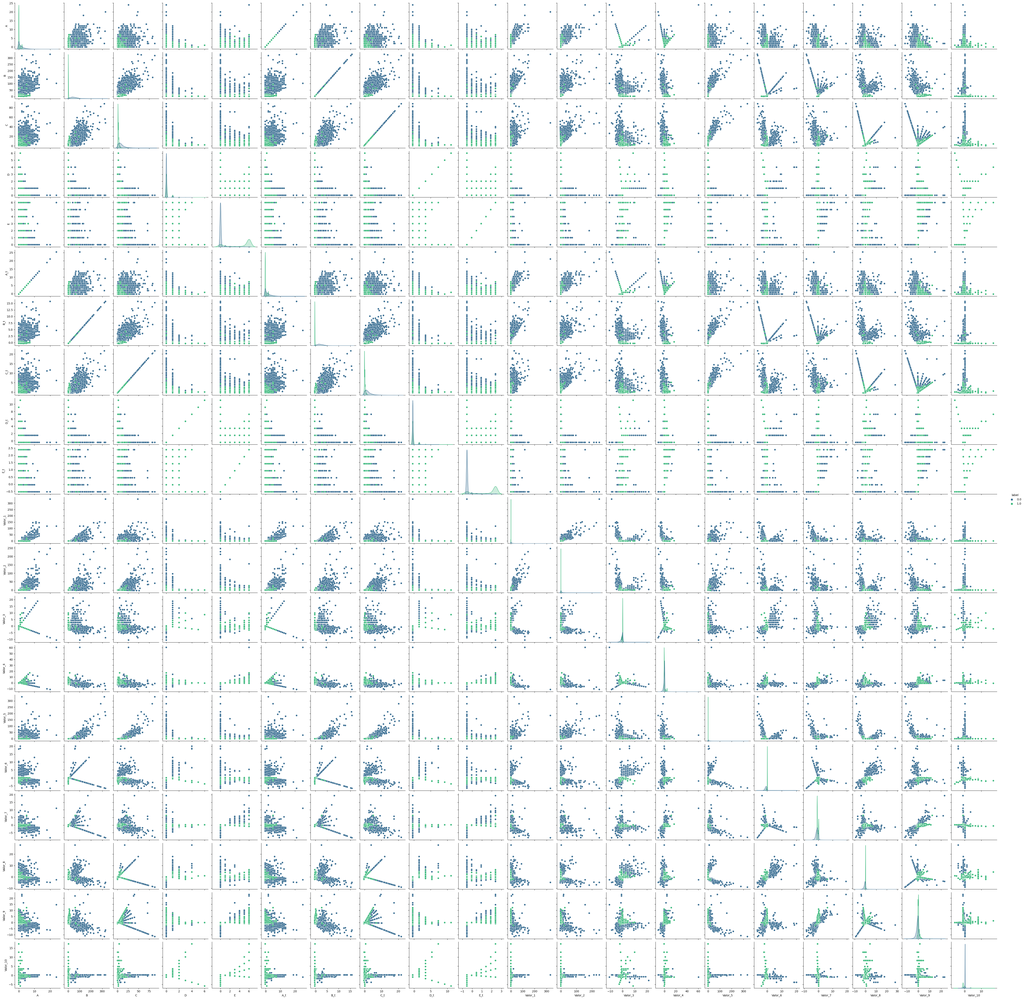

```python
# Crear una matriz de gráficos de dispersión (pairplot)

import seaborn as sns
import matplotlib.pyplot as plt

cols = [col for col in data.columns if col != 'label']
data_pairplot = data[cols + ['label']]

sns.pairplot(data_pairplot, hue='label', palette='viridis', diag_kind='kde')

plt.show()
```

Distribuciones. Los diferentes colores de los puntos se refieren a las label.

```python
# Eliminar columnas que empiecen por 'Valor_' y la columna 'comentario'

cols_a_eliminar = [col for col in data.columns if col.startswith('Valor_')]

cols_a_eliminar.append('comentario')

data_reducido = data.drop(columns=cols_a_eliminar)

# Mostrar las primeras filas del nuevo dataframe para verifica

data_reducido.head()
```

|  | A | B | C | D | E | label | A_t | B_t | C_t | D_t | E_t |
| --- | --- | --- | --- | --- | --- | --- | --- | --- | --- | --- | --- |
| 0 | 2 | 64 | 30 | 0 | 2 | 0.0 | 1.851102 | 2.759647 | 7.145831 | -0.416577 | 0.440638 |
| 1 | 4 | 70 | 21 | 0 | 0 | 0.0 | 3.990202 | 3.054765 | 4.877255 | -0.416577 | -0.531099 |
| 2 | 4 | 88 | 50 | 0 | 0 | 0.0 | 3.990202 | 3.940120 | 12.187108 | -0.416577 | -0.531099 |
| 3 | 3 | 38 | 21 | 0 | 0 | 0.0 | 2.920652 | 1.480801 | 4.877255 | -0.416577 | -0.531099 |
| 4 | 0 | 59 | 17 | 0 | 0 | 0.0 | -0.287998 | 2.513715 | 3.869000 | -0.416577 | -0.531099 |

```python
# Estandarizar las columnas, excepto 'label'

from sklearn.preprocessing import StandardScaler

X = data_reducido.drop(columns=['label'])
y = data_reducido['label']

scaler = StandardScaler()
X_scaled = scaler.fit_transform(X)
```

El estandarizado es el primer paso para aplicar el algoritmo PCA. Se aplicará el StandardScaler

```python
# Separar las características y las etiquetas

# Ya se ha hecho en la sección anterior, separando las características en X y las etiquetas en y
```

### PCA

```python
# Aplicar PCA
from sklearn.decomposition import PCA

pca = PCA(n_components=2)
data_pca = pca.fit_transform(X)

# Crear un DataFrame con los resultados de PCA
pca_df = pd.DataFrame(data=data_pca, columns=['PC1', 'PC2'])
pca_df['label'] = y.values

pca_df.head()
```

|  | PC1 | PC2 | label |
| --- | --- | --- | --- |
| 0 | 41.746454 | 18.080676 | 0.0 |
| 1 | 46.257753 | 7.909215 | 0.0 |
| 2 | 69.195370 | 34.024751 | 0.0 |
| 3 | 14.719372 | 13.278487 | 0.0 |
| 4 | 34.466851 | 5.400280 | 0.0 |

En esta primera implementación de pca, se realiza para que la representación sea en 2D, tal como indica el enunciado. Por ello, el num de componentes es 2. El objetivo es obtener los dos componentes que más varianza de los datos explican.

```python
# Visualizar los resultados de PCA

explained_variances = pca.explained_variance_ratio_
eigenvalues = pca.explained_variance_
eigenvectors = pca.components_
pcs = np.arange(1, len(explained_variances) + 1)
```

En el bloque anterior se definen las varianzas, los autovalores y los autovectores. La primera metrica indica lla proporcion de varianza total de los datos que explica cada uno de los componentes. Descpués, se obtienen los autovalores que representan la cantidad de varianza en escala absoluta que cada componente explica. Los autovectores, posteriormente, indican los peseos de cada variable origianl en cada componente. Es decir, indica la manera en la que se han construido los componentes.

```python
print("Contribución de cada Componente Principal (PC):")
for i, variance in enumerate(explained_variances):
    print(f"PC{i+1}: {variance * 100:.2f}% de la varianza total")
```

```
Contribución de cada Componente Principal (PC):
PC1: 97.40% de la varianza total
PC2: 1.71% de la varianza total
```

PCA ha creado dos componentes. EL primero explica el 97.4% de la varianza. Casi toda la información importante está concentrada en pc1.

```python
print("Autovalores (Valores Propios):")
for i, eigenvalue in enumerate(eigenvalues):
    print(f"Autovalor {i + 1}: {eigenvalue:.4f}")
```

```
Autovalores (Valores Propios):
Autovalor 1: 1200.7966
Autovalor 2: 21.0950
```

```python
print("Autovectores (Vectores Propios):")
for i, eigenvector in enumerate(eigenvectors):
    print(f"Autovector {i + 1}: {eigenvector}")
```

```
Autovectores (Vectores Propios):
Autovector 1: [ 2.90711573e-02  9.81252730e-01  1.69646692e-01 -7.68431235e-04
 -4.39757991e-02  3.10930543e-02  4.82642821e-02  4.27618056e-02
 -1.47294656e-03 -2.13664442e-02]
Autovector 2: [ 0.04196036 -0.17018928  0.94630161  0.00387544  0.10919384  0.0448787
 -0.008371    0.23852847  0.00742853  0.05305382]
```

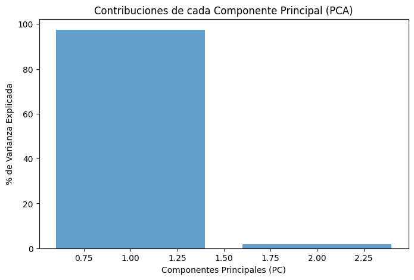

```python
import matplotlib.pyplot as plt

plt.figure(figsize=(8, 5))
plt.bar(pcs, explained_variances * 100, alpha=0.7)
plt.xlabel('Componentes Principales (PC)')
plt.ylabel('% de Varianza Explicada')
plt.title('Contribuciones de cada Componente Principal (PCA)')
plt.show()
```

En el gráfico anterior se puede valorar de forma muy visual la manera en la que PC1 (el de la izquierda) aporta prácticamente toda la explicación de la varianza.

```
Número de componentes seleccionados: 2
Varianza explicada por estos componentes: 99.11%
```

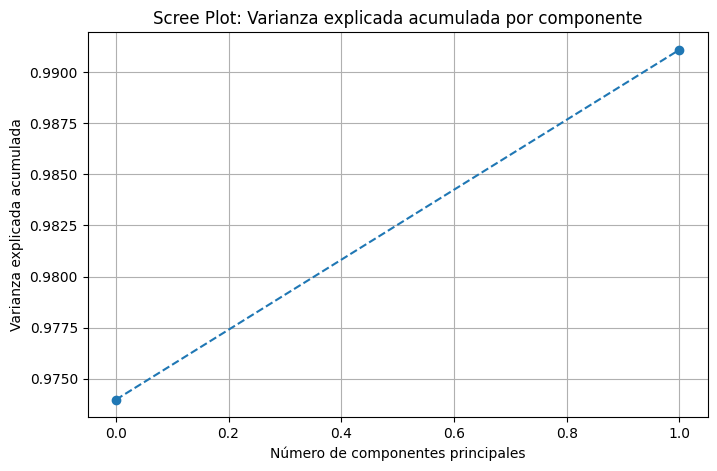

```python
include_screeplot = True

if include_screeplot:
    n_components_selected = pca.n_components_
    explained_variance_ratio = explained_variances.sum()
    print(f"Número de componentes seleccionados: {n_components_selected}")
    print(f"Varianza explicada por estos componentes: {explained_variance_ratio * 100:.2f}%")

    plt.figure(figsize=(8, 5))
    plt.plot(np.cumsum(explained_variances), marker='o', linestyle='--')
    plt.title('Scree Plot: Varianza explicada acumulada por componente')
    plt.xlabel('Número de componentes principales')
    plt.ylabel('Varianza explicada acumulada')
    plt.grid(True)
    plt.show()
```

Este grafico indica la forma en la que varía también el añadir más componentes en el porcentaje de varianza explicada. Con dos componentes se explica practicamente toda la varianza, aunque sólo con una también se obtienen muy buenos resultados

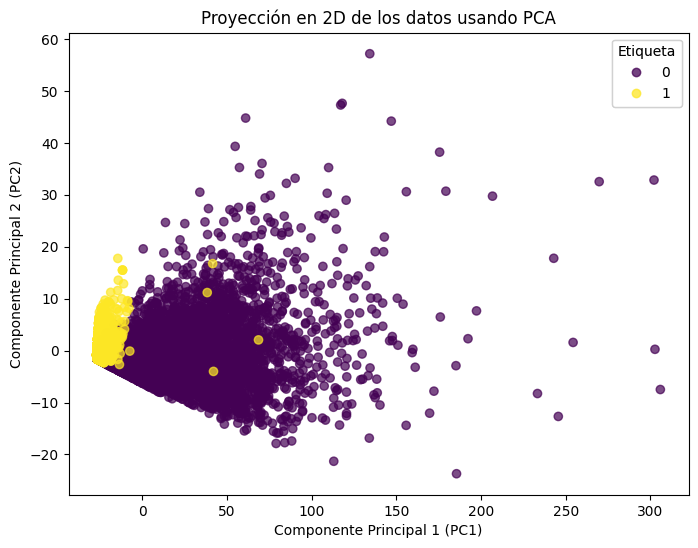

```python
import matplotlib.pyplot as plt

plt.figure(figsize=(8, 6))

scatter = plt.scatter(pca_df['PC1'], pca_df['PC2'], c=pca_df['label'], cmap='viridis', alpha=0.7)

plt.xlabel('Componente Principal 1 (PC1)')
plt.ylabel('Componente Principal 2 (PC2)')
plt.title('Proyección en 2D de los datos usando PCA')

legend = plt.legend(*scatter.legend_elements(), title='Etiqueta')
plt.gca().add_artist(legend)

plt.show()
```

El gráfico presenta la proyección en 2d de los datos tras aplicar PCA. Se puede observar que los puntos amarillos de la clase 1 tienen un valor de PC1 bajo, y en cuanto pasa un umbral prácticamente todos son morados, clase 0. En este gráfico se puede evaluar muy visualmente la manera en la que PC1 captura casi toda la varianza.

```python
# Dividir los datos en conjunto de entrenamiento y prueba


# Entrenar un modelo de clasificación (por ejemplo, RandomForest)

# Predecir y evaluar el modelo
```

En primer lugar, se va a entrenar un modelo sin aplicar PCA para evaluar sus resultados en comparación con el modelo tras aplicar PCA. Se va autilizar un modelo simple random forest. El objetivo será no es crear un modelo extraordinario, sino comparar el uso de pca con no utilizar pca

```python
from sklearn.model_selection import train_test_split
from sklearn.ensemble import RandomForestClassifier
from sklearn.metrics import accuracy_score, classification_report, confusion_matrix

X_train_orig, X_test_orig, y_train, y_test = train_test_split(X_scaled, y, test_size=0.3, random_state=42, stratify=y)

rf_orig = RandomForestClassifier(random_state=42)
rf_orig.fit(X_train_orig, y_train)

y_pred_orig = rf_orig.predict(X_test_orig)

accuracy_orig = accuracy_score(y_test, y_pred_orig)
print(f'Accuracy (sin PCA): {accuracy_orig:.4f}')

print("\nClassification Report (sin PCA):")
print(classification_report(y_test, y_pred_orig))

print("\nConfusion Matrix (sin PCA):")
print(confusion_matrix(y_test, y_pred_orig))
```

```
Accuracy (sin PCA): 0.9773

Classification Report (sin PCA):
              precision    recall  f1-score   support

         0.0       0.98      0.97      0.98      1500
         1.0       0.97      0.98      0.98      1500

    accuracy                           0.98      3000
   macro avg       0.98      0.98      0.98      3000
weighted avg       0.98      0.98      0.98      3000


Confusion Matrix (sin PCA):
[[1460   40]
 [  28 1472]]
```

```python
from sklearn.decomposition import PCA

pca = PCA(n_components=2)
X_pca = pca.fit_transform(X_scaled)

X_train_pca, X_test_pca, _, _ = train_test_split(X_pca, y, test_size=0.3, random_state=42, stratify=y)

rf_pca = RandomForestClassifier(random_state=42)
rf_pca.fit(X_train_pca, y_train)

y_pred_pca = rf_pca.predict(X_test_pca)

accuracy_pca = accuracy_score(y_test, y_pred_pca)
print(f'\nAccuracy (con PCA): {accuracy_pca:.4f}')

print("\nClassification Report (con PCA):")
print(classification_report(y_test, y_pred_pca))

print("\nConfusion Matrix (con PCA):")
print(confusion_matrix(y_test, y_pred_pca))
```

```
Accuracy (con PCA): 0.9707

Classification Report (con PCA):
              precision    recall  f1-score   support

         0.0       0.98      0.96      0.97      1500
         1.0       0.96      0.98      0.97      1500

    accuracy                           0.97      3000
   macro avg       0.97      0.97      0.97      3000
weighted avg       0.97      0.97      0.97      3000


Confusion Matrix (con PCA):
[[1444   56]
 [  32 1468]]
```

### t-SNE

En este apartado, se va a implementar la técnica t-SNE, que funciona mejor cuando los datos son no lineales. Para garantizar que la comparativa es fiable, se va a implementar t-sne y se va a visualizar la representación n-D de los componentes creados, que seguirán siendo dos (2D)

También se parte de los datos escalados.

Para este caso, se ha establecido un valor de perplexity de 30, que es el num de vecinos cercanos que se consideran al tratar de mantener las relaciones de similitud. Es decir, es el hiperparámetro que indica a cuántos puntos debe mirar para establecer similitudes

```python
# Aplicar t-SNE

from sklearn.manifold import TSNE

tsne = TSNE(n_components=2, random_state=42, perplexity=30, n_iter=1000)
X_tsne = tsne.fit_transform(X_scaled)
```

```python
# Crear un DataFrame con los resultados de t-SNE

tsne_df = pd.DataFrame(data=X_tsne, columns=['TSNE1', 'TSNE2'])
tsne_df['label'] = y.values

print(tsne_df.head())
```

```
        TSNE1      TSNE2  label
0   57.425083   5.371038    0.0
1   79.097252  29.649950    0.0
2   64.489128  19.357805    0.0
3  103.269363  23.505571    0.0
4   68.912270 -17.131750    0.0
```

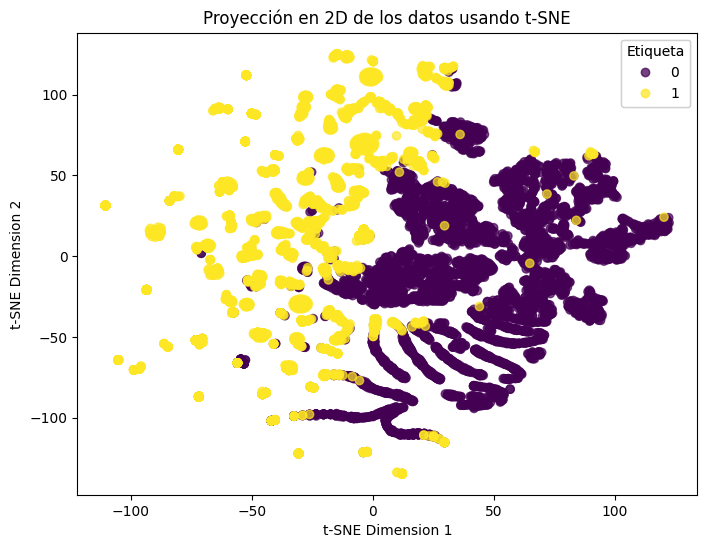

```python
# Visualizar los resultados de t-SNE

import matplotlib.pyplot as plt

# Graficar
plt.figure(figsize=(8, 6))
scatter = plt.scatter(tsne_df['TSNE1'], tsne_df['TSNE2'], c=tsne_df['label'], cmap='viridis', alpha=0.7)

plt.xlabel('t-SNE Dimension 1')
plt.ylabel('t-SNE Dimension 2')
plt.title('Proyección en 2D de los datos usando t-SNE')

# Añadir leyenda
legend = plt.legend(*scatter.legend_elements(), title='Etiqueta')
plt.gca().add_artist(legend)

plt.show()
```

#### Analice los resultados obtenidos por t-SNE

En primer lugar, el tiempo de cómputo de tsne es mucho más alto que el de PCA. Sin embargo, en este gráfico se observa una división entre cllases muy clara y están más separadas, además de racimos y patrones característicos.

En la implementación con pca no se observaba esto y los grupos eran más densos. Puede sugerir que hay relaciones no lineales en los datos. PCA mostraba que la clase 1 estaba agrupada en una región, mientras que tsne captura una separación mucho más clara y con mucho más detalle. Aunque PCA daba buenos resultados, parece que t-SNE captura relaciones que pca no era capaz

### Utilizar t-SNE para clasificar

```python
# Dividir los datos en conjunto de entrenamiento y prueba


# Entrenar un modelo de clasificación (por ejemplo, RandomForest)

# Predecir y evaluar el modelo
```

```python
from sklearn.model_selection import train_test_split
from sklearn.ensemble import RandomForestClassifier
from sklearn.metrics import accuracy_score, classification_report, confusion_matrix

X_train_orig, X_test_orig, y_train, y_test = train_test_split(X_scaled, y, test_size=0.3, random_state=42, stratify=y)

rf_orig = RandomForestClassifier(random_state=42)
rf_orig.fit(X_train_orig, y_train)

y_pred_orig = rf_orig.predict(X_test_orig)

accuracy_orig = accuracy_score(y_test, y_pred_orig)
print(f'Accuracy (sin t-SNE): {accuracy_orig:.4f}')

print("\nClassification Report (sin t-SNE):")
print(classification_report(y_test, y_pred_orig))

print("\nConfusion Matrix (sin t-SNE):")
print(confusion_matrix(y_test, y_pred_orig))
```

```
Accuracy (sin t-SNE): 0.9773

Classification Report (sin t-SNE):
              precision    recall  f1-score   support

         0.0       0.98      0.97      0.98      1500
         1.0       0.97      0.98      0.98      1500

    accuracy                           0.98      3000
   macro avg       0.98      0.98      0.98      3000
weighted avg       0.98      0.98      0.98      3000


Confusion Matrix (sin t-SNE):
[[1460   40]
 [  28 1472]]
```

```python
X_train_tsne, X_test_tsne, _, _ = train_test_split(X_tsne, y, test_size=0.3, random_state=42, stratify=y)

rf_tsne = RandomForestClassifier(random_state=42)
rf_tsne.fit(X_train_tsne, y_train)

y_pred_tsne = rf_tsne.predict(X_test_tsne)

accuracy_tsne = accuracy_score(y_test, y_pred_tsne)
print(f'\nAccuracy (con t-SNE): {accuracy_tsne:.4f}')

print("\nClassification Report (con t-SNE):")
print(classification_report(y_test, y_pred_tsne))

print("\nConfusion Matrix (con t-SNE):")
print(confusion_matrix(y_test, y_pred_tsne))
```

```
Accuracy (con t-SNE): 0.9783

Classification Report (con t-SNE):
              precision    recall  f1-score   support

         0.0       0.98      0.98      0.98      1500
         1.0       0.98      0.98      0.98      1500

    accuracy                           0.98      3000
   macro avg       0.98      0.98      0.98      3000
weighted avg       0.98      0.98      0.98      3000


Confusion Matrix (con t-SNE):
[[1467   33]
 [  32 1468]]
```

Se va a realizar lo mismo que antes. Se entrenará el modelo sin tsne y luego con tsne con el fin de interpretar correctamente el resultado

Los datos obtenidos indican que mejora el rendimiento utilizando tsne, ya que obtiene mejor accuracy y clasifica mejor una de las clases

#### ¿Se puede utilizar la reducción de dimensinalidad obtenida por t-SNE para entrenar un algoritmo de clasificación?

Aunque es posible utilizar t-SNE para entrenar, no es la mejor idea debido a que no está pensado para ello. Uno de los grandes problemas que presenta es que no es determinista, es decir, que si se corre dos veces puede dar resultados diferetes e introducir inestabilidad. Además, solo muestra agrupamientos pero las distancias absolutas pueden no ser importantes para modelos de clasificación.

Además, como se ha indicado en fragmentos anteriores, se ha observado que computacionalmente es más costoso, y si el dataset crece puede no ser eficiente. Y sólo transforma las dimensiones para los datos que corre directamente, pero no genera transformaciones predefinidas para poder proyectar nuevos puntos, al igual que si hace PCA.

t_SNE está pensado para visualización, no para entrenar modelos

Como conlusión, auqneu tsne ha dado mejores resultados incluso que el modelo 'normal', es peligroso de utilizar por lo que se comentó anteriormente. POr ello, se concluye que el modelo a utilizar para este tipo de casos es pca

### LDA

El primer paso será cargar de nuevo el dataset y luego ir realizando los pasos indicados

```python
import pandas as pd
import numpy as np
import matplotlib.pyplot as plt

file_path = 'out.csv'
data = pd.read_csv(file_path)

print(data.columns)
```

```
Index(['A', 'B', 'C', 'D', 'E', 'comentario', 'label', 'A_t', 'B_t', 'C_t',
       'D_t', 'E_t', 'Valor_1', 'Valor_2', 'Valor_3', 'Valor_4', 'Valor_5',
       'Valor_6', 'Valor_7', 'Valor_8', 'Valor_9', 'Valor_10'],
      dtype='object')
```

```python
# Descargar las palabras vacías en español

import nltk
nltk.download('stopwords')
```

```
True
```

```python
from nltk.corpus import stopwords
spanish_stopwords = stopwords.words('spanish')
```

```python
# Preprocesar la columna 'comentario'

import re

def preprocess_text(text):
    text = text.lower()
    text = re.sub(r'[^\w\s]', '', text)
    words = text.split()
    words = [word for word in words if word not in spanish_stopwords]
    return ' '.join(words)

data['comentario_clean'] = data['comentario'].apply(preprocess_text)
```

```python
from sklearn.feature_extraction.text import CountVectorizer
from sklearn.decomposition import LatentDirichletAllocation

# Vectorizar textos
vectorizer = CountVectorizer()
X_text = vectorizer.fit_transform(data['comentario_clean'])
```

En este caso, se han pasado a minúsculas los comentarios, se han eliminado los signos de puntuación y se han eliminado todas las stopwords para limpiar bien el texto. Después se han vectorizado para obtener la matriz documento-término donde cada fila es un comentario y cada columna una palabra ya limpiada

```python
# Aplicar LDA

lda = LatentDirichletAllocation(n_components=5, random_state=42)
lda.fit(X_text)
```

```
LatentDirichletAllocation(n_components=5, random_state=42)
```

Se han incluido cinco temáticas diferentes a modod de prueba

```python
# Mostrar los temas

def display_topics(model, feature_names, no_top_words):
    for topic_idx, topic in enumerate(model.components_):
        print(f"Temática {topic_idx + 1}:")
        print(" ".join([feature_names[i] for i in topic.argsort()[:-no_top_words - 1:-1]]))

no_top_words = 10
feature_names = vectorizer.get_feature_names_out()
display_topics(lda, feature_names, no_top_words)
```

```
Temática 1:
idiota lameculo daiasco subnormal desgraciado manipulador hdgp periodismobasura ponerbozalputamadre irotomarculo
Temática 2:
asqueroso asco imbecil sinverguenzar mierda patetico sergilipol almudenamfsinverguenza fascista asesino
Temática 3:
terroristainformativo hdlgp sinverguenza gentuzar tonto miserable vacunarputamadre mentiroso mundobasuraperiodistico inutil
Temática 4:
terrorismoinformativo poderseguirbabeliafacebooktwitterapuntarteaquirecibirnewslettersemanal hijoputo basura verguenza putamadre escorio panfletoasquerosoreaccionariovomitivo hijogranputa vaisarrestarilegalmenteputamadre
Temática 5:
payaso hijoputa panfleto engañabobo panfletobasura golfo menudosinverguenza diariomierdo jeta gilipol
```

Preprocesamiento: Este paso convierte el texto en una matriz de términos. Aplicación de LDA: Ejecuta el algoritmo LDA para encontrar los temas. Visualización de Temas: Imprime los temas encontrados con las palabras más representativas.

### LDA en función del label

En este caso, se aplica LDA pero para cada una de las clases (0 y 1) con el objetivo de encontrar relaciones en cada una de ellas de forma independienteº

```python
import pandas as pd
import numpy as np
import matplotlib.pyplot as plt

file_path = 'out.csv'
data = pd.read_csv(file_path)

print(data.columns)
```

```
Index(['A', 'B', 'C', 'D', 'E', 'comentario', 'label', 'A_t', 'B_t', 'C_t',
       'D_t', 'E_t', 'Valor_1', 'Valor_2', 'Valor_3', 'Valor_4', 'Valor_5',
       'Valor_6', 'Valor_7', 'Valor_8', 'Valor_9', 'Valor_10'],
      dtype='object')
```

```python
# Descargar las palabras vacías en español

import nltk

from nltk.corpus import stopwords
spanish_stopwords = stopwords.words('spanish')

import re

def preprocess_text(text):
    text = text.lower()
    text = re.sub(r'[^\w\s]', '', text)
    words = text.split()
    words = [word for word in words if word not in spanish_stopwords]
    return ' '.join(words)
```

```python
# Definir función para aplicar LDA y obtener temas

from sklearn.feature_extraction.text import CountVectorizer
from sklearn.decomposition import LatentDirichletAllocation
import pandas as pd

def apply_lda_and_get_topics(df, n_topics=5, n_top_words=10):
    df['comentario_clean'] = df['comentario'].apply(preprocess_text)

    vectorizer = CountVectorizer()
    X = vectorizer.fit_transform(df['comentario_clean'])

    lda = LatentDirichletAllocation(n_components=n_topics, random_state=42)
    lda.fit(X)

    feature_names = vectorizer.get_feature_names_out()

    topics = []
    for idx, topic in enumerate(lda.components_):
        top_words = [feature_names[i] for i in topic.argsort()[:-n_top_words - 1:-1]]
        topics.append({'Tema': f'Tema {idx + 1}', 'Palabras': ', '.join(top_words)})

    topics_df = pd.DataFrame(topics)
    return topics_df, lda, vectorizer, X
```

```python
# Aplicar LDA por cada etiqueta de label y guardar en archivos CSV
    # Crear un DataFrame para los temas
    # Guardar el DataFrame en un archivo CSV

data_0 = data[data['label'] == 0]
data_1 = data[data['label'] == 1]

topics_0, lda_0, vectorizer_0, X_0 = apply_lda_and_get_topics(data_0)
topics_0.to_csv('temas_label_0.csv', index=False)

topics_1, lda_1, vectorizer_1, X_1 = apply_lda_and_get_topics(data_1)
topics_1.to_csv('temas_label_1.csv', index=False)
```

```python
# Generar bolsas de palabras para cada tema

def get_bag_of_words_per_topic(lda_model, feature_names, n_top_words=10):
    bags = {}
    for idx, topic in enumerate(lda_model.components_):
        top_words = [feature_names[i] for i in topic.argsort()[:-n_top_words - 1:-1]]
        bags[f'Tema {idx + 1}'] = top_words
    return bags

feature_names_0 = vectorizer_0.get_feature_names_out()
bags_0 = get_bag_of_words_per_topic(lda_0, feature_names_0)
print("Bolsas de palabras para label 0:")
print(bags_0)
```

[output not shown]

```python
# Asignar temas a comentarios

import numpy as np

def assign_dominant_topic(lda_model, X):
    topic_assignments = lda_model.transform(X)
    dominant_topics = np.argmax(topic_assignments, axis=1)
    return dominant_topics

dominant_topics_0 = assign_dominant_topic(lda_0, X_0)
data_0['tema_asignado'] = dominant_topics_0

dominant_topics_1 = assign_dominant_topic(lda_1, X_1)
data_1['tema_asignado'] = dominant_topics_1
```

```python
# Generar bolsas de palabras para cada etiqueta
tema_counts_0 = data_0['tema_asignado'].value_counts()
tema_counts_1 = data_1['tema_asignado'].value_counts()

print("\nFrecuencia de temas en label 0:")
print(tema_counts_0)

print("\nFrecuencia de temas en label 1:")
print(tema_counts_1)
```

```
Frecuencia de temas en label 0:
tema_asignado
2    1007
1    1005
3    1004
4     994
0     990
Name: count, dtype: int64

Frecuencia de temas en label 1:
tema_asignado
0    1036
4     999
1     993
3     993
2     979
Name: count, dtype: int64
```

Se crea un resumen sobre los temas dominantes de cada etiqueta

```python
# Asignar temas a todos los comentarios y comparar con etiquetas reales
data_0['label'] = 0
data_1['label'] = 1
data_full = pd.concat([data_0, data_1])

comparacion = data_full[['label', 'tema_asignado']]
print(comparacion.head())

contingencia = pd.crosstab(data_full['label'], data_full['tema_asignado'])
print("\nMatriz de comparación entre etiquetas reales y temas asignados:")
print(contingencia)
```

```
   label  tema_asignado
0      0              1
1      0              2
2      0              4
3      0              4
4      0              0

Matriz de comparación entre etiquetas reales y temas asignados:
tema_asignado     0     1     2     3    4
label
0               990  1005  1007  1004  994
1              1036   993   979   993  999
```

Se ha hecho un análisis de los temas más frecuentes en cada una de las labels. De esta manera, se puede comprender qué palabras o temas son más comunes en cada una de ellas, para poder detectar si alguno de ellos es frecuente en una y no en otra. Por ejemplo, el tema 0 es el más común en label 1 y el menos en label 0. Pese a que las diferencias en cuanto a comentarios tampoco son enormes, esto puede mostrar indicios de palabras que pueden indicar o no odio y debe ser analizado